# A3: SPL Library Checkouts

### Introduction

I’m a big fan of podcasts, particularly ones related to real world events and ideas. So for this assignment I’ll be looking into analyzing the relevance of nonfiction books, with a particular focus on audio books. I’ll be pulling data from the 2017-2023-10-Checkouts-SPL-Data.csv file to hopefully see patterns between nonfiction and audiobook checkouts. It’s also important to note that the items in this list were checked out at least 10 times in a month and the data was pulled from 2017 to 2023.

### The Dataset

The Seattle Public Library and the city of Seattle collaborated with third party groups to collect and eventually publish the data. The parameters of the data range from what the material type the book was to when the checkout year was. They also include the following: title, checkout month, author, number of checkouts, publisher, publication year, etc. The Checkout data comes from multiple current and historical sources. For digital items, the media vendors: Overdrive, hoopla, Freegal, and RBDigital provided usage data. For physical item checkouts, the source of this data is the Legrady artwork data archives. For October 1 2016 to present, the source is the Horizon ILS. The seattle.gov website phrases it like, “Seattle is home to an engaged, innovative public that strives to make the city a better place to live. As a City, we strive to make our data open to the public, enabling those outside of government to find solutions to our most pressing civic challenges.” They say that this Open Data Program makes the data generated by the City of Seattle available to the public for the purposes of increasing the quality of life for residents and all by increasing transparency, accountability and comparability; promoting economic development and research; and improving internal performance management. A few ethical questions that you could pose when working with this data is to ask yourself if this data is representative of a large and diverse amount of Seattle residents or not? Some limitations is that this dataset only counts initial checkouts, which means longer books that may be renewed multiple times may not get fair representation among the rest of the items in the data set.

### First Trends Over Time Chart

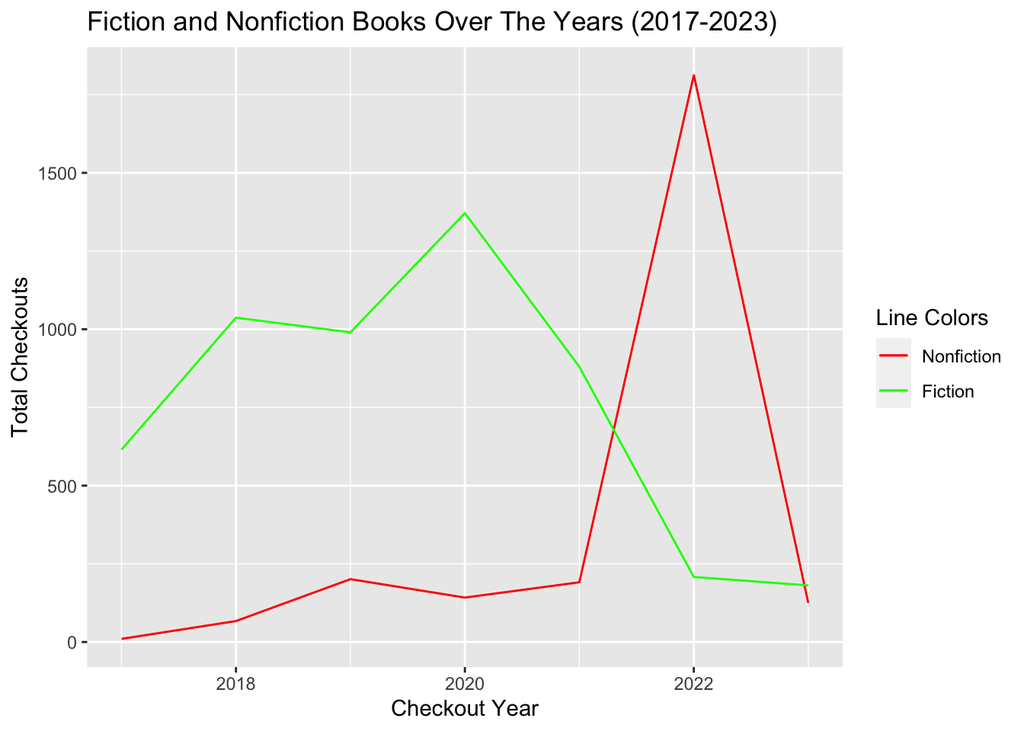

### Second Trends Over Time Chart

Analysis:

Similarly to the last graph, here I chose to graph the number of physical books compared to audiobooks that were checked out from 2017 to 2023. I decided to include this data visualization to try to show if people, in more recent times, were switching to other digital forms of information seeking like audiobooks or podcasts. Something I didn’t expect was a sharp drop in checkouts after 2022 for both material types. Could it be an error in the dataset? Could it be that less people are visiting libraries in general? Again, it’s hard to tell but it would be interesting to look into further. Here’s the graph below..

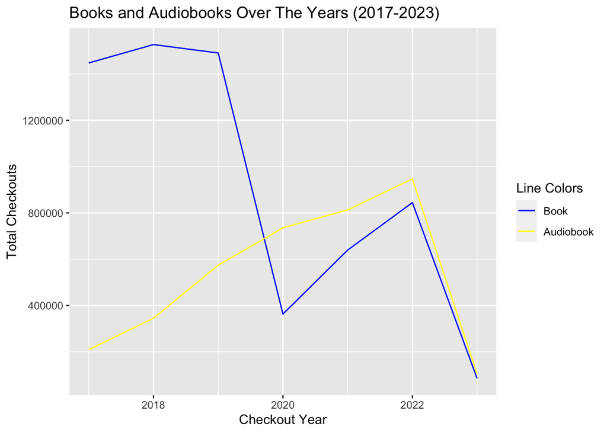

### Your Choice

Analysis:

For this last chart, I decided to stick with visualizing trends over time but this time I used a bar chart. I’m a big fan of listening to podcasts, so while that form of media wasn’t included in the dataset the closest thing to it was audiobooks. So here I graphed the number of checkouts of nonfiction audiobooks from 2017 to 2023. Another interesting trend was how, again, during the height of the pandemic there was a clear increase in the number of audiobooks checked out. I found this pattern funny becuase it was also when I probably spent the most time listening to podcasts. Here’s the graph below..

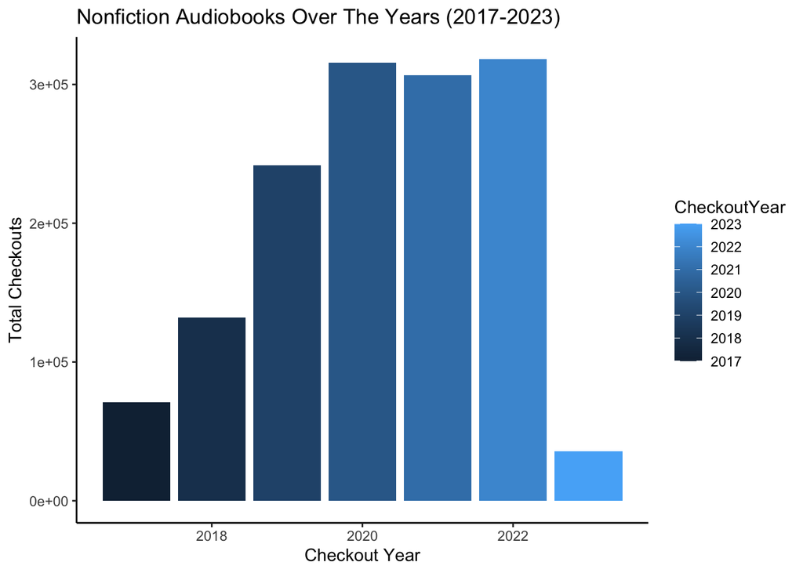